# Kaggle Heart Disease Classification

Interpretable binary classification with validation and calibration

Matheus Assis de Oliveira

June 26, 2026

# Abstract

This article presents the final project in the current portfolio roadmap: a Kaggle heart disease classification workflow. The dataset contains 303 records and a heart disease prevalence of 54.5%. The workflow compares logistic regression and decision tree models with stratified validation, ROC-AUC, confusion metrics, calibration bins, and standardized coefficient interpretation. The selected model is logistic, with holdout ROC-AUC of 0.863, accuracy of 80.3%, sensitivity of 87.9%, and specificity of 71.4%. This is a portfolio benchmark, not a clinical decision tool.

# Introduction

Heart disease classification is a classic structured-data benchmark. It is useful for a portfolio because it requires the analyst to handle categorical-style numerical variables, evaluate binary classification metrics, and communicate model limits.

The research question is:

```
Which variables help classify heart disease presence,
and how can the model remain interpretable?
```

# Data

Dataset summary.

| Item | Value |
| --- | --- |
| Canonical source | Kaggle Heart Disease Dataset |
| Records | 303 |
| Predictors | 13 |
| Outcome prevalence | 54.5% |
| Target | Heart disease presence |

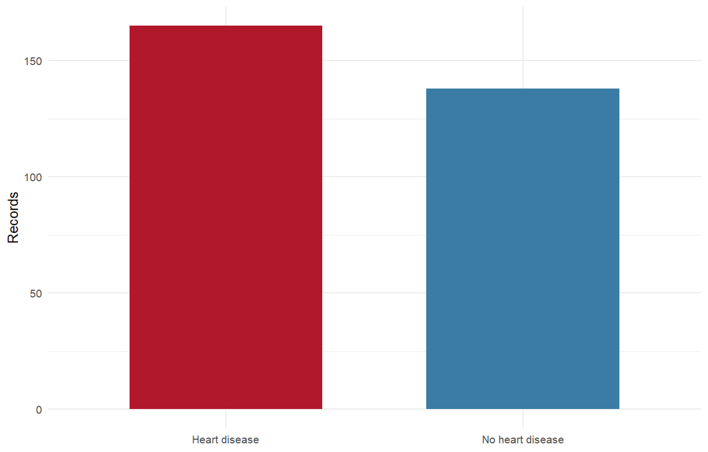

Outcome distribution.

# Methods

The workflow uses a stratified 80/20 holdout split and five-fold stratified cross-validation on the training set. Logistic regression is trained on standardized predictors, while the decision tree uses the original numeric feature scale. ROC-AUC is computed manually, and confusion metrics are reported at threshold 0.50.

# Results

## Holdout Metrics

Holdout model metrics at threshold 0.50.

| Model | Accuracy | Sensitivity | Specificity | Precision | F1 | ROC-AUC |
| --- | --- | --- | --- | --- | --- | --- |
| logistic | 80.3% | 87.9% | 71.4% | 78.4% | 82.9% | 0.863 |
| tree | 73.8% | 69.7% | 78.6% | 79.3% | 74.2% | 0.746 |

## Confusion Matrix

Selected-model holdout confusion matrix.

| Observed | Predicted | Records |
| --- | --- | --- |
| No heart disease | No heart disease | 20 |
| No heart disease | Heart disease | 8 |
| Heart disease | No heart disease | 4 |
| Heart disease | Heart disease | 29 |

## ROC Curve

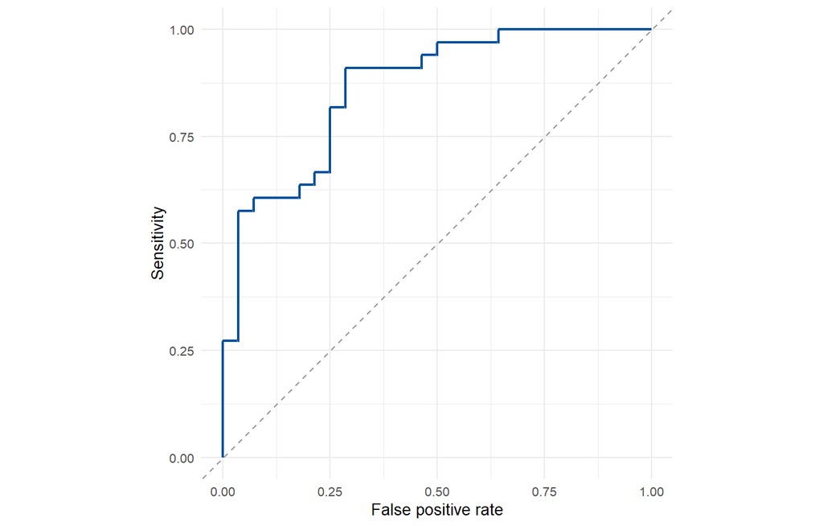

Selected-model ROC curve.

## Cross-Validation

Five-fold cross-validation summary.

| Model | Accuracy | Sensitivity | Specificity | F1 | Mean ROC-AUC |
| --- | --- | --- | --- | --- | --- |
| logistic | 82.2% | 87.2% | 76.4% | 84.3% | 0.906 |
| tree | 79.8% | 80.4% | 79.1% | 81.2% | 0.829 |

## Variable Interpretation

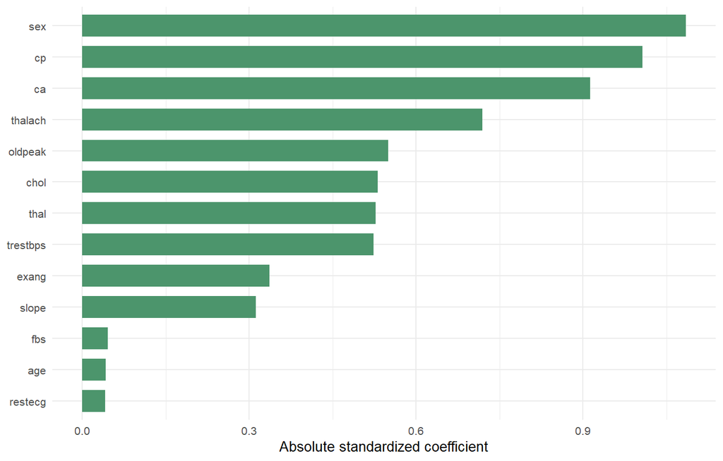

Logistic regression variable importance.

Standardized logistic regression coefficients.

| Variable | Coefficient | Direction |
| --- | --- | --- |
| sex | -1.085 | Lower probability |
| cp | 1.007 | Higher probability |
| ca | -0.913 | Lower probability |
| thalach | 0.719 | Higher probability |
| oldpeak | -0.550 | Lower probability |
| chol | -0.532 | Lower probability |
| thal | -0.527 | Lower probability |
| trestbps | -0.524 | Lower probability |
| exang | -0.337 | Lower probability |
| slope | 0.312 | Higher probability |
| fbs | -0.046 | Lower probability |
| age | -0.042 | Lower probability |
| restecg | 0.041 | Higher probability |

## Calibration

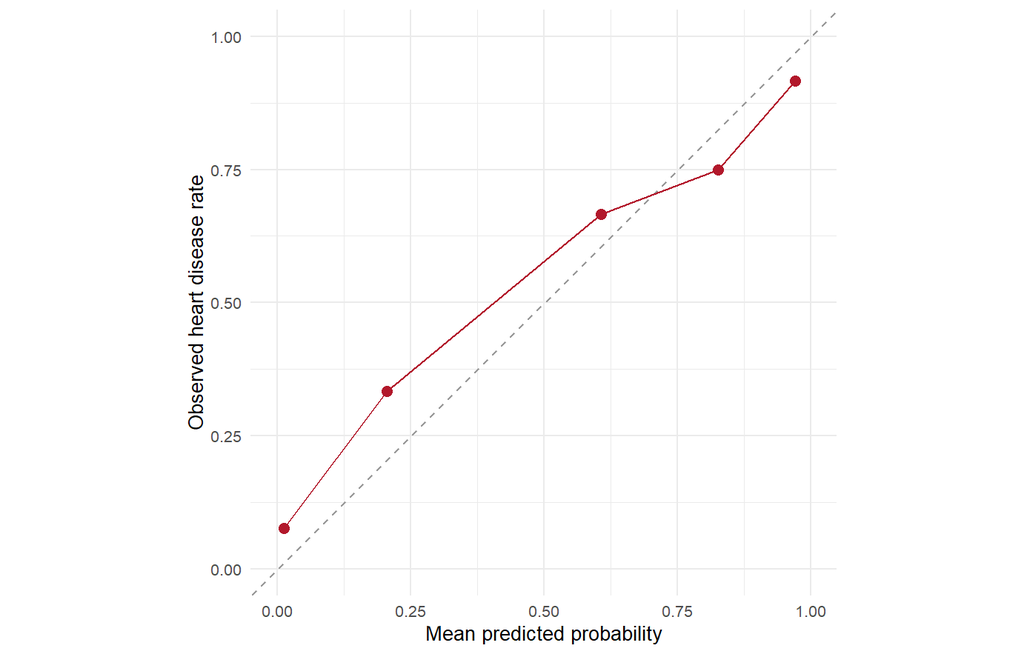

Calibration bins for the selected model.

# Discussion

The selected model provides an interpretable classification benchmark. Logistic regression coefficients show which standardized predictors are associated with higher or lower predicted probability, while the decision tree provides a simple nonlinear comparison.

The model should be read as a teaching and portfolio artifact. In clinical settings, threshold choice would depend on screening goals, harm tradeoffs, prevalence, and external validation.

# Limitations

The dataset is small, benchmark-oriented, and not sufficient for medical deployment. It lacks longitudinal clinical history, medications, symptoms, diagnostic imaging, care pathways, and representative sampling. The output is not medical advice, diagnosis, triage, or a clinical recommendation.

# Conclusion

S14 completes the current portfolio roadmap with a validated, interpretable heart disease classification project. The workflow includes model comparison, ROC-AUC, confusion metrics, calibration, variable interpretation, and careful clinical limitations.

# References

Kaggle Heart Disease Dataset. https://www.kaggle.com/datasets/johnsmith88/heart-disease-dataset

UCI Heart Disease Dataset. https://archive.ics.uci.edu/dataset/45/heart+disease

Public CSV mirror used for local reproducibility. https://raw.githubusercontent.com/kb22/Heart-Disease-Prediction/master/dataset.csv